# Reproducible Research: Peer Assessment 1

### 1.Loading and Preprocessing the data

```r
setwd("C:/Users/Family/Desktop/Coursera/RDA/WK2")
if(!file.exists("mfdata")) {dir.create("./mfdata")}
fileUrl <- "https://d396qusza40orc.cloudfront.net/repdata%2Fdata%2Factivity.zip"
download.file(fileUrl, destfile = "./mfdata/Factivity.zip")
unzip("./mfdata/Factivity.zip", exdir = "./mfdata")
cls = c("integer", "character", "integer")
df <- read.csv("./mfdata/activity.csv", head=TRUE, colClasses=cls, na.strings="NA")
head(df)
```

```
##   steps       date interval
## 1    NA 2012-10-01        0
## 2    NA 2012-10-01        5
## 3    NA 2012-10-01       10
## 4    NA 2012-10-01       15
## 5    NA 2012-10-01       20
## 6    NA 2012-10-01       25
```

Process/transform the data set for analysis later.

Correct the date column and get rid of rows containing missing values.

Save the subset to a new data frame “df1”.

```r
df$date <- as.Date(df$date)
df1 <- subset(df, !is.na(df$steps))
```

### 2.What is mean total number of steps taken per day?

Generate a histogram of the daily total number of steps. The histogram shows the distribution of the totals

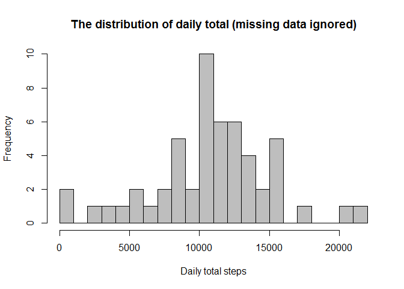

```r
dailysum <- tapply(df1$steps, df1$date, sum, na.rm=TRUE, simplify=T)
dailysum <- dailysum[!is.na(dailysum)]

hist(x=dailysum,
     col="gray",
     breaks=20,
     xlab="Daily total steps",
     ylab="Frequency",
     main="The distribution of daily total (missing data ignored)")
```

Calculate and report mean and median of the total number of steps taken per day

```r
mean(dailysum)
```

```
## [1] 10766.19
```

```r
median(dailysum)
```

```
## [1] 10765
```

The mean is 10766 steps and the median is 10765 steps.

### 3.What is the average daily activity pattern?

Create a time series plot (i.e. type = “l”) of the 5-minute interval (x-axis) and the average number of steps taken, averaged across all days (y-axis)

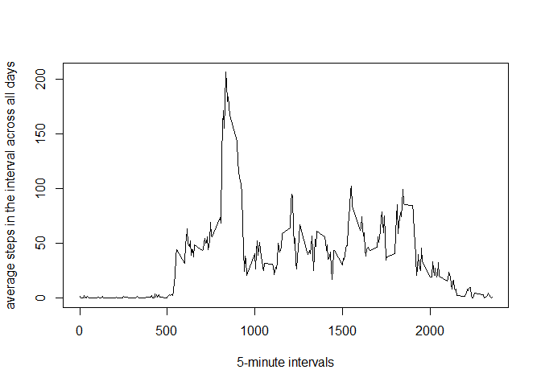

```r
int_avg <- tapply(df1$steps, df1$interval, mean, na.rm=TRUE, simplify=T)
df3 <- data.frame(interval=as.integer(names(int_avg)), avg=int_avg)

with(df3,
     plot(interval,
          avg,
          type="l",
          xlab="5-minute intervals",
          ylab="average steps in the interval across all days"))
```

Determine which 5-minute interval, on average across all the days in the dataset, contains the maximum number of steps.

```r
max_steps <- max(df3$avg)
df3[df3$avg == max_steps, ]
```

```
##     interval      avg
## 835      835 206.1698
```

5-minute interval number 835 contains maximum number of steps. There are 206 steps in this 5-minute interval .

### 4.Imputing missing values

Calculate and report the total number of missing values in the dataset (i.e. the total number of rows with NAs)

```r
sum(is.na(df$steps))
```

```
## [1] 2304
```

The original data set has 2304 rows with missing data.

Strategy:- Use the mean for 5-minute interval across all the days in the dataset to fill in the the missing values in the dataset.

```r
df4 <- df1
ndx <- is.na(df4$steps)
int_avg <- tapply(df1$steps, df1$interval, mean, na.rm=TRUE, simplify=T)
df4$steps[ndx] <- int_avg[as.character(df4$interval[ndx])]
```

Make a histogram of the total number of steps taken each day.

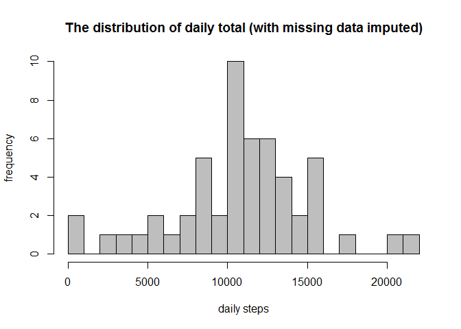

```r
New_dailysum <- tapply(df4$steps, df4$date, sum, na.rm=TRUE, simplify=T)

hist(x=New_dailysum,
     col="Gray",
     breaks=20,
     xlab="daily steps",
     ylab="frequency",
     main="The distribution of daily total (with missing data imputed)")
```

Calculate and report the mean and median total number of steps taken per day.

```r
mean(New_dailysum)
```

```
## [1] 10766.19
```

```r
median(New_dailysum)
```

```
## [1] 10765
```

### 5.Are there differences in activity patterns between weekdays and weekends?

Create a new factor variable “wkid” in the dataset with two levels - “weekday” and “weekend” indicating whether a given date is a weekday or weekend day.

Create new function to use in determining if a day is a week day or not.

```r
is_weekday <- function(d) {
    wd <- weekdays(d)
    ifelse (wd == "Saturday" | wd == "Sunday", "weekend", "weekday")
}

wx <- sapply(df4$date, is_weekday)
df4$wkid <- as.factor(wx)
head(df4)
```

```
##     steps       date interval    wkid
## 289     0 2012-10-02        0 weekday
## 290     0 2012-10-02        5 weekday
## 291     0 2012-10-02       10 weekday
## 292     0 2012-10-02       15 weekday
## 293     0 2012-10-02       20 weekday
## 294     0 2012-10-02       25 weekday
```

Make a panel plot containing a time series plot (i.e. type = “l”) of the 5-minute interval (x-axis) and the average number of steps taken, averaged across all weekday days or weekend days (y-axis).

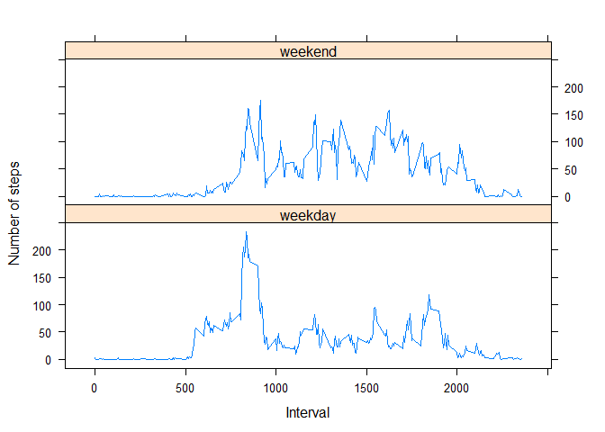

```r
wkid_df <- aggregate(steps ~ wkid+interval, data=df4, FUN=mean)

library(lattice)
xyplot(steps ~ interval | factor(wkid),
       layout = c(1, 2),
       xlab="Interval",
       ylab="Number of steps",
       type="l",
       lty=1,
       data=wkid_df)
```

The panel plot shows the difference in activity patterns as follows

Weekday activities starts earlier than the weekend activities. Weekday activities start between 5.00am and 6.00am, peaks at around 9.am and maintains lower activity levels compared to weekend activities.Weekday activities end earlier than the weekend activities

#### This is the last page ………………….